# Week 1 Assignment – Data Wrangling and PCA

Randy Sprouse

11/03/2024

```r
# Load packages
library(tidyverse)
library(flextable)
library(ggcorrplot)
library(factoextra)

# Read in the data
data1 <- read_csv("penguins1.csv")
data2 <- read_csv("penguins2.csv")

# Combine datasets
full_data <- rbind(data1, data2)

# Verify merge
print(nrow(data1))
```

```
## [1] 175
```

```r
print(nrow(data2))
```

```
## [1] 169
```

```r
print(nrow(full_data))
```

```
## [1] 344
```

```r
if (nrow(data1) + nrow(data2) == nrow(full_data)) {
  print("The datasets have been successfully merged")
}
```

```
## [1] "The datasets have been successfully merged"
```

```r
str(full_data)
```

```
## spc_tbl_ [344 × 5] (S3: spec_tbl_df/tbl_df/tbl/data.frame)
##  $ culmen_length_mm : num [1:344] 58 46.4 49.2 42.4 48.5 43.2 50.6 46.7 52 50.5 ...
##  $ culmen_depth_mm  : num [1:344] 17.8 18.6 18.2 17.3 17.5 16.6 19.4 17.9 19 18.4 ...
##  $ flipper_length_mm: num [1:344] 181 190 195 181 191 187 193 195 197 200 ...
##  $ body_mass_g      : num [1:344] 3700 3450 4400 3600 3400 2900 3800 3300 4150 3400 ...
##  $ sex              : chr [1:344] "FEMALE" "FEMALE" "MALE" "FEMALE" ...
##  - attr(*, "spec")=
##   .. cols(
##   ..   culmen_length_mm = col_double(),
##   ..   culmen_depth_mm = col_double(),
##   ..   flipper_length_mm = col_double(),
##   ..   body_mass_g = col_double(),
##   ..   sex = col_character()
##   .. )
##  - attr(*, "problems")=<externalptr>
```

```r
# Remove non-numeric column for PCA
quant.dat <- full_data
quant.dat$sex <- NULL

# Remove rows with NA or negative values
quant.dat <- quant.dat[apply(quant.dat, 1, function(x) all(!is.na(x) & x >= 0)), ]

# Review cleaned data
print(head(quant.dat))
```

```
## # A tibble: 6 × 4
##   culmen_length_mm culmen_depth_mm flipper_length_mm body_mass_g
##              <dbl>           <dbl>             <dbl>       <dbl>
## 1             58              17.8               181        3700
## 2             46.4            18.6               190        3450
## 3             49.2            18.2               195        4400
## 4             42.4            17.3               181        3600
## 5             48.5            17.5               191        3400
## 6             43.2            16.6               187        2900
```

```r
# Scale the data
scaled.dat <- data.frame(scale(quant.dat))
head(scaled.dat)
```

|  | culmen_length_mm | culmen_depth_mm | flipper_length_mm | body_mass_g |
| --- | --- | --- | --- | --- |
| 1 | 2.5809030 | 0.33591042 | -0.13074959 | -0.6240785 |
| 2 | 0.4501619 | 0.74282144 | -0.09616923 | -0.9353874 |
| 3 | 0.9644787 | 0.53936593 | -0.07695792 | 0.2475864 |
| 4 | -0.2845764 | 0.08159103 | -0.13074959 | -0.7486021 |
| 5 | 0.8358995 | 0.18331878 | -0.09232697 | -0.9976492 |
| 6 | -0.1376288 | -0.27445611 | -0.10769601 | -1.6202671 |

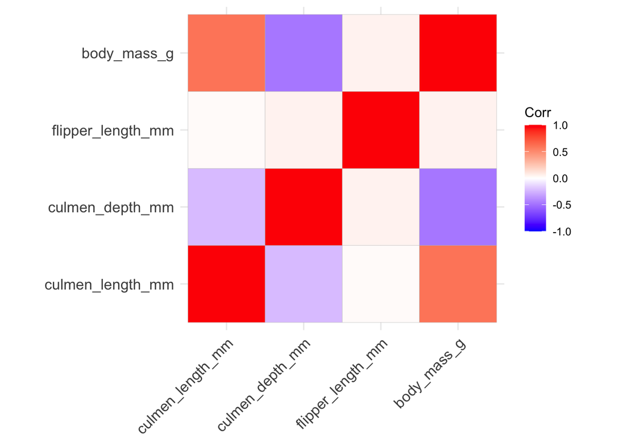

```r
# Correlation matrix
corr_matrix <- cor(scaled.dat)
ggcorrplot(corr_matrix)
```

```r
# PCA
data.pca <- princomp(corr_matrix)
summary(data.pca)
```

```
## Importance of components:
##                           Comp.1    Comp.2     Comp.3 Comp.4
## Standard deviation     0.8909361 0.4440581 0.19521233      0
## Proportion of Variance 0.7713497 0.1916186 0.03703162      0
## Cumulative Proportion  0.7713497 0.9629684 1.00000000      1
```

```r
data.pca$loadings[, 1:2]
```

```
##                       Comp.1      Comp.2
## culmen_length_mm   0.4952256  0.25378500
## culmen_depth_mm   -0.6004035  0.36489638
## flipper_length_mm -0.1229073 -0.89538433
## body_mass_g        0.6157605 -0.02703166
```

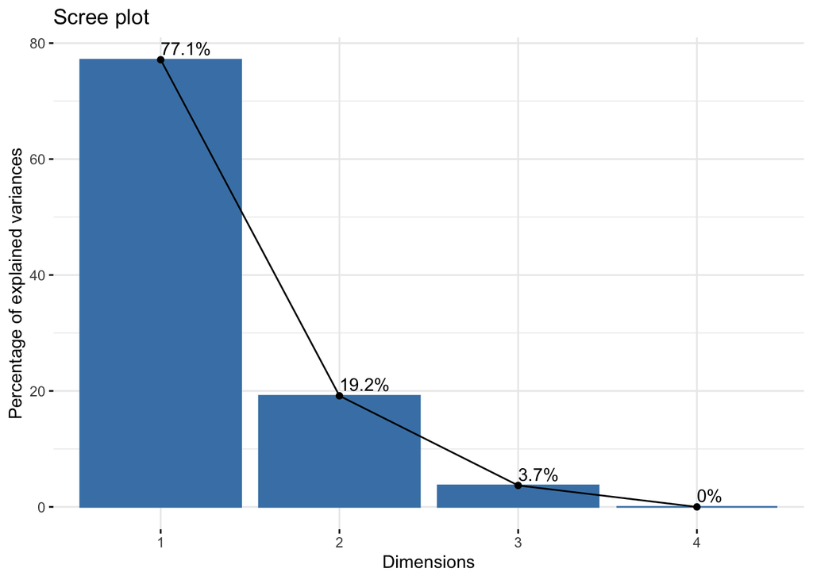

```r
# Scree plot
fviz_eig(data.pca, addlabels = TRUE)
```

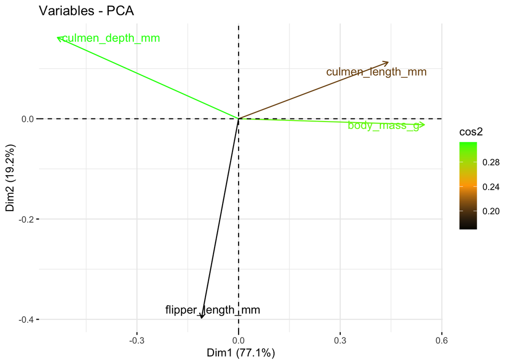

```r
# Biplot
fviz_pca_var(data.pca, col.var = "cos2",
             gradient.cols = c("black", "orange", "green"),
             repel = TRUE)
```

### In your script using hashtags, please interpret the results of you PCA. You don’t need to write a dissertation, but a few sentences about the major outcome of your analysis will suffice.

The importance of components summary tells us that the first 2 components explain 96% of the variance in the data. Components 3 has a low standard deviation and doesn’t have as much of an impact. Component 4 does not contribute to the variance at all.

Base on this analysis, I can say that reducing the dimensionality to the first two principal components is justified without loosing significant information.

The `culmen_length_mm` has a positive loading of `0.4952` indicating that it contributes positively to this component 1 while `culmen_depth_mm` has a negative loading of `-0.6004` indicating an inverse relationship with component 1.

Component 2 seems to be driven primarily by flipper length in an opposite direction to culmen depth and length. This component might represent a factor contrasting flipper length with culmen dimensions.